# A3: Incarceration

### Introduction

The problem domain of this dataset that I chose to study and analyze is the disproportionate makeup of prisons in the United States regarding the population and ratio of Black inmates to White inmates. I want to analyze the variations in ratios of Black to White inmates across prisons specifically, since this assignment is related to incarceration, so I’m only using the CSV file related to prison population per county/state. My variables of interest in this data set are `year`, `state`, `total_prison_pop`, `black_prison_pop`, and `white_prison_pop`. I specifically chose to only analyze the Black and White populations because Black people make up a disproportional amount in U.S prisons compared to White people, so observing how those ratios vary across states would help corroborate the findings showcased in the documentary 13th, while heavily focused on this unbalanced population ratio.

### Summary Information

My two main variables of interest are Black to White prison population ratios and total average population counts. To further explore these variables and get myself familiar with them, I first calculated the `total_average_black_population` and `total_average_white_population`, which was about 247 for White and 162 for Black. These values are not a good picture of the real proportions as this data spans across almost 50 years worth of data, most of which are NA or extremely low numbers. Then I calculated the average `black_to_white_ratio`, grouped by state to create a data frame of only the states and their respective `black_to_white_ratio`. From this data frame, called `average_prison_ratios`, I arranged it in descending order from greatest ratio to lowest ratio and filtered out the top 10 states into a variable called `sorted_ratio_states`. The highest `black_to_white_ratio` among these states was “LA” or Louisiana, stored in the variable `highest_state`. The `black_to_white_ratio` for LA was around 3.165, meaning there were on average over 3 times as many Black inmates than White inmates in Louisiana prisons, stored in the variable `highest_ratio`. This is a significant number which will be studied further on, along with the other states, later on in this analysis.

### The Dataset

Who collected the data?

This data was collected by the Vera Institute of Justice.

How was the data collected or generated?

The data was collected through an assembly of information collected by the U.S Department of Justice Statistics (BJS), with additional data from state departments of correction.

Why was the data collected?  
The data was collected to understand the contours and patterns of incarceration in the U.S, especially in context of race, as much of the information on prison populations have been insufficient to have more robust and theoretically-grounded studies. The county-level variability within these data sets allow for a deeper analysis.

How many observations (rows) are in your data?

There are 153611 observations in the prison dataset.

How many features (columns) are in the data?

There are 38 columns/variables in the prison dataset.

What, if any, ethical questions or questions of power do you need to consider when working with this data?

There are some important ethical questions that must be asked when working and analyzing this data, mostly related to the lack of context surrounding these observations and population counts of prisons. We don’t know if the data about certain population sizes in prisons, especially in regards to race, is even accurate or represented properly. We also must ask ourselves, as students, the kinds of conclusions we will be drawing from these types of data, which is solely based on population counts, and gives no insight to the treatment, crimes, or situations of the people who make up this data. These data sets are more than just numbers, they represent actual human beings.

What are possible limitations or problems with this data? (at least 200 words)

There are a lot of limitations with this data, the biggest one being the massive amounts of missing population data. It was shocking to see that numerous states contained absolutely zero information about their prison populations and racial/gender makeup over the span of nearly 50 years for some regions. This creates a lot of problems in the analysis and interpretation of the graphs, tables, and findings since a large chunk of the data that could either support or refute a certain conclusion is missing. My variable of interest, the ratio of Black to White inmate populations is thus severely unsupported due to this missing data. It raises questions as to why these states either, refused to report or didn’t report, on their prison population counts. Another limitation to the data, that I mentioned about when talking about ethics, was the lack of context given to these counts. While these data sets are incredible on their own and contain a mass amount of prison data that can help draw out importation patterns in our country’s incarceration history, the humanity and stories behind these people are lost. What’s to say a prison contained a small-amount of Black inmates; the immediate conclusion would be that this prison was not disproportionately targeting people of color, yet perhaps those small amount of Black inmates were being treated ten times more poorly than their white counterparts or were locked up for crimes they didn’t commit? So much context is lost through this data and is why the conclusions that are made from this analysis should not be absorbed as the cold and hard truth about our prison system; as most of the issues stay hidden and are systemically embedded into institutions more powerful than prisons.

### Trends Over Time Chart

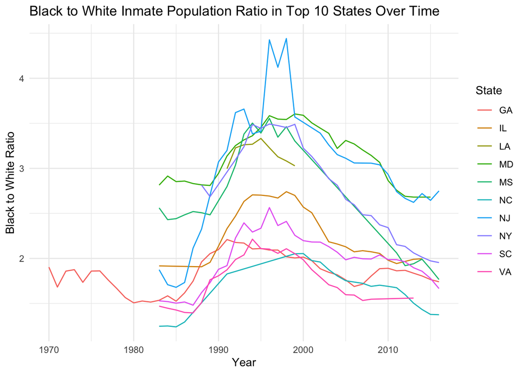

### Variable Comparison Chart

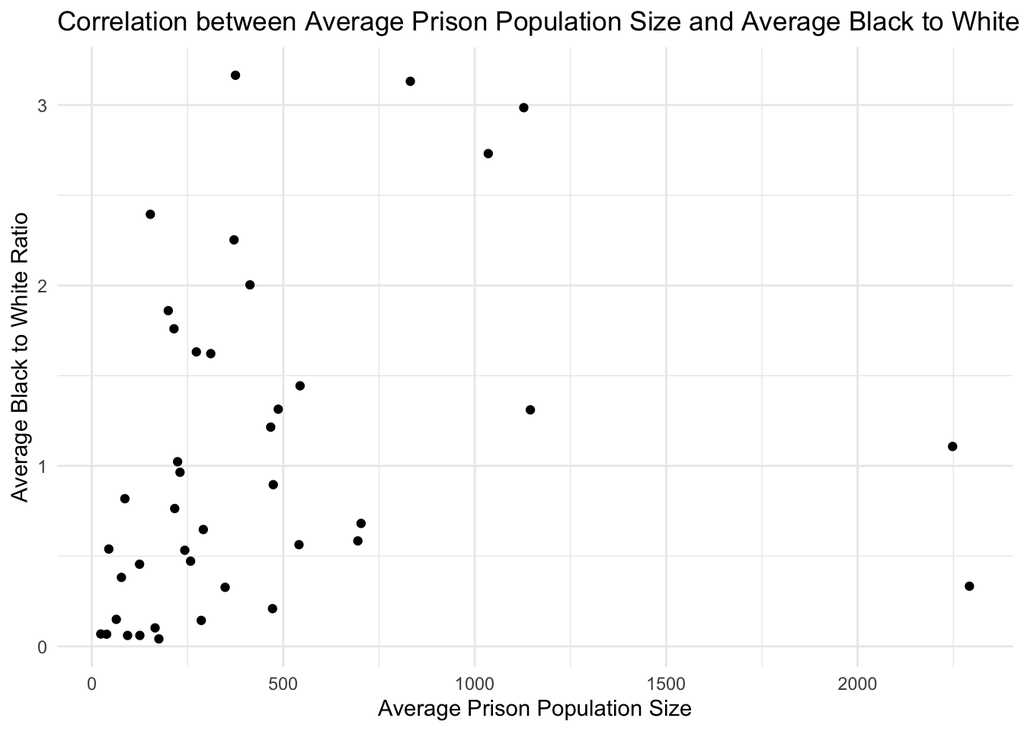

This chart compares the correlation between average prison population and average Black to White prison population ratios for all states in this dataset. I created this scatter plot to see if there was any correlation between larger, more populated prisons, and their demographic ratios between Black and White inmates. There is a slight upwards trend based on this graph that may be evident to larger prisons often housing a disproportionate amount of Black inmates, but overall not enough to fully conclude it, as these averages are often too low due to the time span and the 10 missing values from states who reported zero information on their populations.

### Map

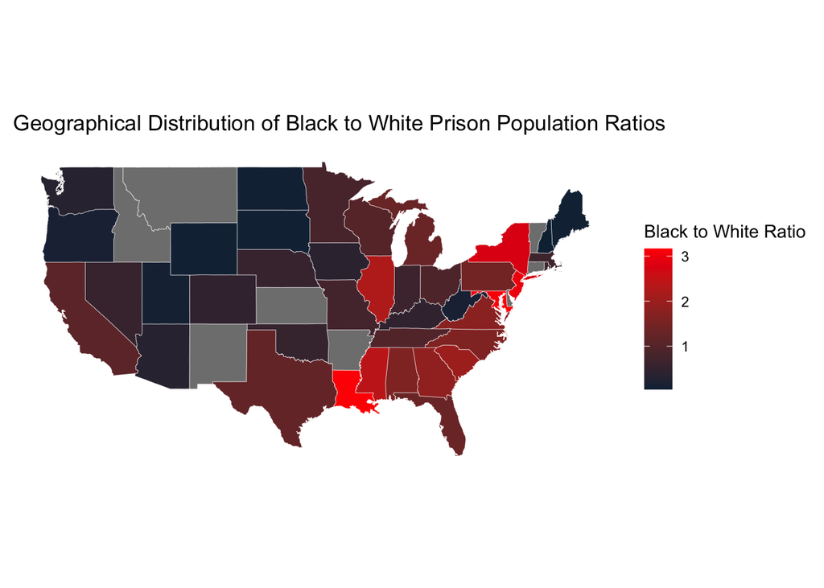

This is a map showcasing the geographical distribution of the variation in `black_to_white_ratio` across the United States. The legend on the side represents the color shading that corresponds to the rounded ratios (1, 2, and 3 meaning that the Black inmate population is x times as large as the White inmate population). There is more red shading in the Southern and East Coast states, states where there are larger populations of Black people, with darker shading in the Central and more Western states, as well as the grey states indicating completely NA ratios/populations that were unfortunately present in the data set.